# Modeling home prices using realtor data

Nimo

1 March 2016

#### Bullet 4,5 and 6

Reading the data into R, removing the columns and renaming the variables;

#### Bullet 7

Preview of the data;

|  | price | size | lot | bath | bed | year | age | garage | status | active | elem |
| --- | --- | --- | --- | --- | --- | --- | --- | --- | --- | --- | --- |
| 1 | 388 | 2.18 | 4 | 3 | 4 | 1940 | -3 | 0 | sld | 0 | edison |
| 2 | 450 | 2.054 | 5 | 3 | 4 | 1957 | -1.3 | 2 | sld | 0 | edison |
| 3 | 386 | 2.112 | 5 | 2 | 4 | 1955 | -1.5 | 2 | sld | 0 | edison |
| 4 | 350 | 1.442 | 6 | 1 | 2 | 1956 | -1.4 | 1 | act | 1 | adams |
| 5 | 155.5 | 1.8 | 1 | 2 | 4 | 1994 | 2.4 | 1 | sld | 0 | adams |
| 6 | 220 | 1.965 | 5 | 2 | 3 | 1940 | -3 | 1 | sld | 0 | adams |
| 7 | 239.5 | 1.8 | 4 | 1.1 | 4 | 1958 | -1.2 | 1 | act | 1 | parker |
| 8 | 207 | 2.254 | 4 | 2 | 4 | 1961 | -0.9 | 2 | sld | 0 | parker |
| 9 | 269.9 | 1.922 | 4 | 2.1 | 4 | 1965 | -0.5 | 2 | act | 1 | parker |
| 10 | 238.8 | 1.92 | 5 | 2.1 | 3 | 1968 | -0.2 | 2 | sld | 0 | parker |

[output cut: 66 more lines]

#### Bullet 8

Performing data exploration;

```
## 'data.frame':    76 obs. of  11 variables:
##  $ price : num  388 450 386 350 156 ...
##  $ size  : num  2.18 2.05 2.11 1.44 1.8 ...
##  $ lot   : int  4 5 5 6 1 5 4 4 4 5 ...
##  $ bath  : num  3 3 2 1 2 2 1.1 2 2.1 2.1 ...
##  $ bed   : int  4 4 4 2 4 3 4 4 4 3 ...
##  $ year  : int  1940 1957 1955 1956 1994 1940 1958 1961 1965 1968 ...
##  $ age   : num  -3 -1.3 -1.5 -1.4 2.4 -3 -1.2 -0.9 -0.5 -0.2 ...
##  $ garage: int  0 2 2 1 1 1 1 2 2 2 ...
##  $ status: Factor w/ 3 levels "act","pen","sld": 3 3 3 1 3 3 1 3 1 3 ...
##  $ active: int  0 0 0 1 0 0 1 0 1 0 ...
##  $ elem  : Factor w/ 6 levels "adams","crest",..: 4 4 4 1 1 1 6 6 6 6 ...
```

```
##      price            size            lot              bath
##  Min.   :155.5   Min.   :1.440   Min.   : 1.000   Min.   :1.000
##  1st Qu.:242.8   1st Qu.:1.861   1st Qu.: 3.000   1st Qu.:2.000
##  Median :276.0   Median :1.966   Median : 4.000   Median :2.000
##  Mean   :285.8   Mean   :1.970   Mean   : 3.987   Mean   :2.208
##  3rd Qu.:336.8   3rd Qu.:2.107   3rd Qu.: 5.000   3rd Qu.:3.000
##  Max.   :450.0   Max.   :2.896   Max.   :11.000   Max.   :3.100
##       bed             year           age               garage
##  Min.   :2.000   Min.   :1905   Min.   :-6.50000   Min.   :0.000
##  1st Qu.:3.000   1st Qu.:1958   1st Qu.:-1.22500   1st Qu.:1.000
##  Median :3.000   Median :1970   Median :-0.05000   Median :2.000
##  Mean   :3.447   Mean   :1969   Mean   :-0.05921   Mean   :1.566
##  3rd Qu.:4.000   3rd Qu.:1980   3rd Qu.: 1.00000   3rd Qu.:2.000
##  Max.   :6.000   Max.   :2005   Max.   : 3.50000   Max.   :3.000
##  status       active           elem
##  act:25   Min.   :0.0000   adams : 3
##  pen:13   1st Qu.:0.0000   crest : 6
##  sld:38   Median :0.0000   edge  :26
##           Mean   :0.3289   edison:12
##           3rd Qu.:1.0000   harris:14
##           Max.   :1.0000   parker:15
```

```
##    price  size lot bath bed year  age garage status active   elem
## 1  388.0 2.180   4  3.0   4 1940 -3.0      0    sld      0 edison
## 2  450.0 2.054   5  3.0   4 1957 -1.3      2    sld      0 edison
## 3  386.0 2.112   5  2.0   4 1955 -1.5      2    sld      0 edison
## 4  350.0 1.442   6  1.0   2 1956 -1.4      1    act      1  adams
## 5  155.5 1.800   1  2.0   4 1994  2.4      1    sld      0  adams
## 6  220.0 1.965   5  2.0   3 1940 -3.0      1    sld      0  adams
## 7  239.5 1.800   4  1.1   4 1958 -1.2      1    act      1 parker
## 8  207.0 2.254   4  2.0   4 1961 -0.9      2    sld      0 parker
## 9  269.9 1.922   4  2.1   4 1965 -0.5      2    act      1 parker
## 10 238.8 1.920   5  2.1   3 1968 -0.2      2    sld      0 parker
```

Price appears to be affected by the following variables: size, lot, bath, bed, age and garage.

#### Bullet 9 and 10

The range for prize in thousands of dollars is;

```
## [1] 155.5 450.0
```

The range for size in thousands of square feet is;

```
## [1] 1.440 2.896
```

Creating models using forward selection and backward elimination;

```
## Start:  AIC=624.17
## price ~ 1
##
##          Df Sum of Sq    RSS    AIC
## + elem    5     60570 212433 615.11
## + garage  1     35065 237938 615.73
## + bed     1     22361 250641 619.68
## + lot     1     16284 256718 621.50
## + size    1     11078 261925 623.03
## + active  1      9219 263784 623.56
## + bath    1      8328 264674 623.82
## <none>                273002 624.17
## + age     1      6485 266517 624.35
##
## Step:  AIC=615.11
## price ~ elem
##
##          Df Sum of Sq    RSS    AIC
## + garage  1     40716 171717 600.94
## + lot     1     35860 176573 603.06
## + bed     1     19964 192469 609.61
## + age     1     17610 194823 610.53
## + active  1     14549 197884 611.72
## + size    1     12382 200051 612.55
## <none>                212433 615.11
## + bath    1      4284 208149 615.56
##
## Step:  AIC=600.94
## price ~ elem + garage
##
##          Df Sum of Sq    RSS    AIC
## + lot     1   18261.9 153455 594.39
## + size    1    7010.3 164707 599.77
## + active  1    5486.8 166230 600.47
## <none>                171717 600.94
## + bed     1    4075.2 167642 601.11
## + bath    1    1625.2 170092 602.22
## + age     1    1183.4 170534 602.41
##
## Step:  AIC=594.39
```

[output cut: 21 more lines]

```
## price ~ elem + garage + lot + active + size
##
##        Df Sum of Sq    RSS    AIC
## + bed   1    4696.1 129216 587.33
## <none>              133912 588.04
## + age   1    1895.9 132016 588.96
## + bath  1     211.9 133700 589.92
##
## Step:  AIC=587.33
## price ~ elem + garage + lot + active + size + bed
##
##        Df Sum of Sq    RSS    AIC
## <none>              129216 587.33
## + age   1    723.98 128492 588.90
## + bath  1    551.18 128665 589.00
```

```
## Start:  AIC=590.71
## price ~ size + lot + bath + bed + age + garage + active + elem
##
##          Df Sum of Sq    RSS    AIC
## - bath    1       314 128492 588.90
## - age     1       487 128665 589.00
## - garage  1      2398 130576 590.12
## <none>                128178 590.71
## - bed     1      3797 131975 590.93
## - size    1     10354 138532 594.62
## - active  1     11650 139828 595.33
## - lot     1     17488 145666 598.43
## - elem    5     73498 201676 615.16
##
## Step:  AIC=588.9
## price ~ size + lot + bed + age + garage + active + elem
##
##          Df Sum of Sq    RSS    AIC
## - age     1       724 129216 587.33
## - garage  1      2444 130936 588.33
## <none>                128492 588.90
## - bed     1      3524 132016 588.96
## - active  1     12181 140674 593.78
## - size    1     14199 142691 594.87
## - lot     1     17201 145693 596.45
## - elem    5     77457 205949 614.75
##
## Step:  AIC=587.33
## price ~ size + lot + bed + garage + active + elem
##
##          Df Sum of Sq    RSS    AIC
## <none>                129216 587.33
## - garage  1      4299 133515 587.81
## - bed     1      4696 133912 588.04
## - active  1     12460 141676 592.32
## - size    1     15696 144912 594.04
## - lot     1     16479 145695 594.45
## - elem    5     79837 209054 613.89
```

From the results, they both result in the same model.

#### Bullet 11

Regressing all variables except status and year;

```
##
## Call:
## lm(formula = price ~ size + lot + bath + bed + age + garage +
##     active + elem, data = HP)
##
## Residuals:
##     Min      1Q  Median      3Q     Max
## -87.265 -27.217  -0.222  30.125  95.583
##
## Coefficients:
##             Estimate Std. Error t value Pr(>|t|)
## (Intercept)   88.144     57.780   1.526  0.13214
## size          69.782     30.934   2.256  0.02756 *
## lot           10.750      3.667   2.932  0.00469 **
## bath           4.615     11.748   0.393  0.69575
## bed          -12.459      9.120  -1.366  0.17676
## age            1.626      3.324   0.489  0.62643
## garage        10.053      9.261   1.086  0.28182
## active        30.874     12.902   2.393  0.01971 *
## elemcrest      4.809     34.067   0.141  0.88819
## elemedge       7.466     29.050   0.257  0.79802
## elemedison    87.195     30.810   2.830  0.00624 **
## elemharris    53.786     30.629   1.756  0.08394 .
## elemparker   -11.904     30.009  -0.397  0.69296
## ---
## Signif. codes:  0 '***' 0.001 '**' 0.01 '*' 0.05 '.' 0.1 ' ' 1
##
## Residual standard error: 45.11 on 63 degrees of freedom
## Multiple R-squared:  0.5305, Adjusted R-squared:  0.4411
## F-statistic: 5.932 on 12 and 63 DF,  p-value: 8.906e-07
```

Plotting the residuals of each variable;

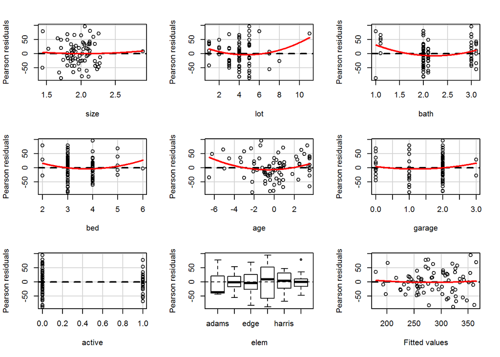

```
##            Test stat Pr(>|t|)
## size           0.303    0.763
## lot            1.979    0.052
## bath           2.376    0.021
## bed            1.011    0.316
## age            2.316    0.024
## garage         0.813    0.419
## active        -2.159    0.035
## elem              NA       NA
## Tukey test     0.333    0.739
```

Based on the residual plots, a non-linear model is more appropriate. The adjusted R-squared value for the model is 0.4411.

#### Bullet 12

Adding the interaction between bath and bed and the square of age to the model;

```
##
## Call:
## lm(formula = price ~ size + lot + bath + bed + age + garage +
##     active + elem + I(age^2) + bath:bed, data = HP)
##
## Residuals:
##     Min      1Q  Median      3Q     Max
## -83.284 -22.628  -0.066  27.790 111.323
##
## Coefficients:
##             Estimate Std. Error t value Pr(>|t|)
## (Intercept) 308.7738   118.9553   2.596  0.01181 *
## size         58.7689    29.2569   2.009  0.04900 *
## lot          10.3619     3.5731   2.900  0.00518 **
## bath        -98.7362    47.9507  -2.059  0.04376 *
## bed         -77.4817    32.3252  -2.397  0.01961 *
## age           3.7771     3.2371   1.167  0.24784
## garage       10.6773     8.7030   1.227  0.22460
## active       30.3572    12.2685   2.474  0.01614 *
## elemcrest    20.0071    32.4456   0.617  0.53977
## elemedge     28.8890    28.2176   1.024  0.30998
## elemedison   88.1039    29.7429   2.962  0.00435 **
## elemharris   69.1235    30.3032   2.281  0.02605 *
## elemparker   14.9554    30.7470   0.486  0.62842
## I(age^2)      1.8236     0.7571   2.409  0.01905 *
## bath:bed     29.6573    13.6582   2.171  0.03380 *
## ---
## Signif. codes:  0 '***' 0.001 '**' 0.01 '*' 0.05 '.' 0.1 ' ' 1
##
## Residual standard error: 42.37 on 61 degrees of freedom
## Multiple R-squared:  0.5989, Adjusted R-squared:  0.5068
## F-statistic: 6.505 on 14 and 61 DF,  p-value: 8.906e-08
```

#### Bullet 13

Using only harris and edison from the column elem;

```
##
## Call:
## lm(formula = price ~ size + lot + bath + bed + age + garage +
##     active + elem + I(age^2) + bath:bed, data = A)
##
## Residuals:
##     Min      1Q  Median      3Q     Max
## -81.692 -25.524   2.122  35.383  69.895
##
## Coefficients:
##               Estimate Std. Error t value Pr(>|t|)
## (Intercept)  6.041e+02  5.240e+02   1.153   0.2670
## size         1.005e+02  9.529e+01   1.055   0.3081
## lot         -5.848e+00  1.333e+01  -0.439   0.6672
## bath        -2.584e+02  2.694e+02  -0.959   0.3526
## bed         -1.651e+02  1.466e+02  -1.126   0.2779
## age         -2.300e+00  6.742e+00  -0.341   0.7378
## garage       4.555e+01  2.357e+01   1.933   0.0724 .
## active       6.750e+00  3.041e+01   0.222   0.8273
## elemharris  -1.063e+01  3.214e+01  -0.331   0.7455
## I(age^2)    -3.262e-03  1.416e+00  -0.002   0.9982
## bath:bed     8.053e+01  7.575e+01   1.063   0.3046
## ---
## Signif. codes:  0 '***' 0.001 '**' 0.01 '*' 0.05 '.' 0.1 ' ' 1
##
## Residual standard error: 52.78 on 15 degrees of freedom
## Multiple R-squared:  0.3987, Adjusted R-squared:  -0.002102
## F-statistic: 0.9948 on 10 and 15 DF,  p-value: 0.488
```

Comparing the last two models;

[output not shown]

#### Bullet 14

Mean square prediction error for the models: Forward selection model;

[output not shown]

Backward elimination model;

```
## [1] 1551.897
```

Model with all variables;

```
## [1] 1546.805
```

Model including age^2 and bath:bed;

```
## [1] 2302.123
```

Model using only harris and edison from elem;

```
## [1] 1387.685
```

#### Bullet 15

```
##    size lot bath bed year age garage active   elem pred.price
## 1 1.879   4  2.5   3 1975 0.5      2      0 parker   242.4466
## 2 1.879   4  2.5   3 1975 0.5      2      1 parker   272.8038
```

#### Bullet 16

Visualising the effects;

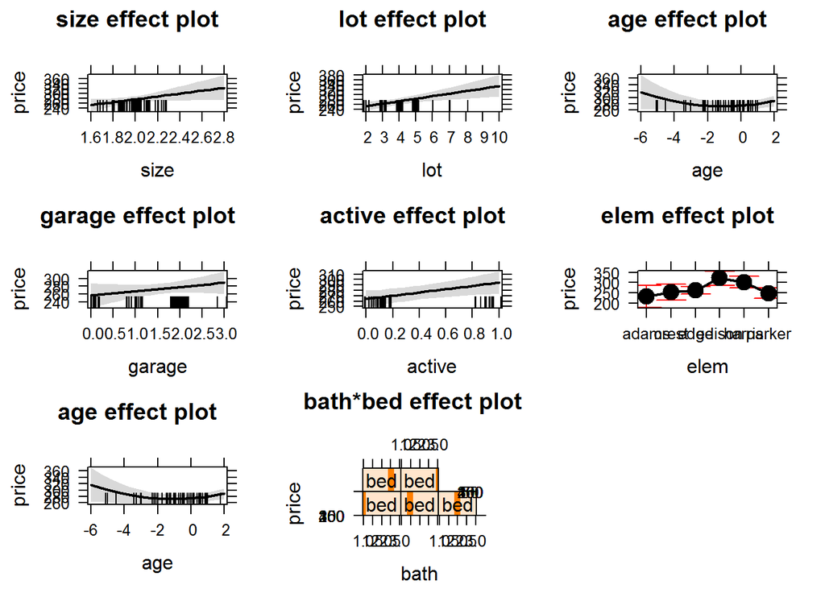

The graphs show that size, lot, garage and active have a positive correlation with price. For the elem varibale, edison has the highest effect on price. Age and age^2 have decreasing effect on price at first then the effect grows as the value becomes positive. For the interaction term between bath and bed, the effect is decresing at first then it increases as the value goes beyond 2.

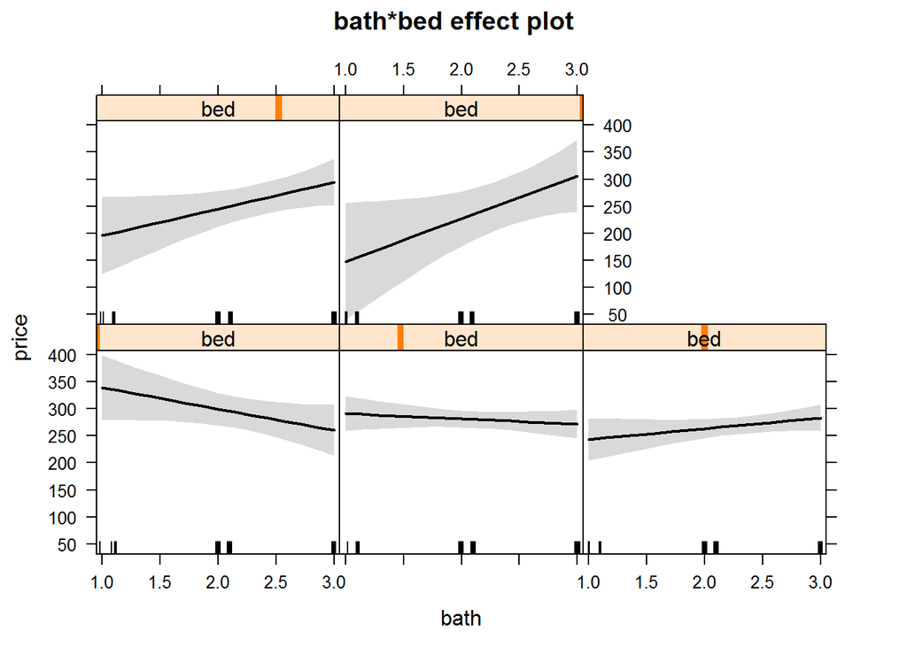

This graph looks at the effect of the interaction term bath:bed on price. The effect of the predictor is decreasing at lower values then it increases at higher values.

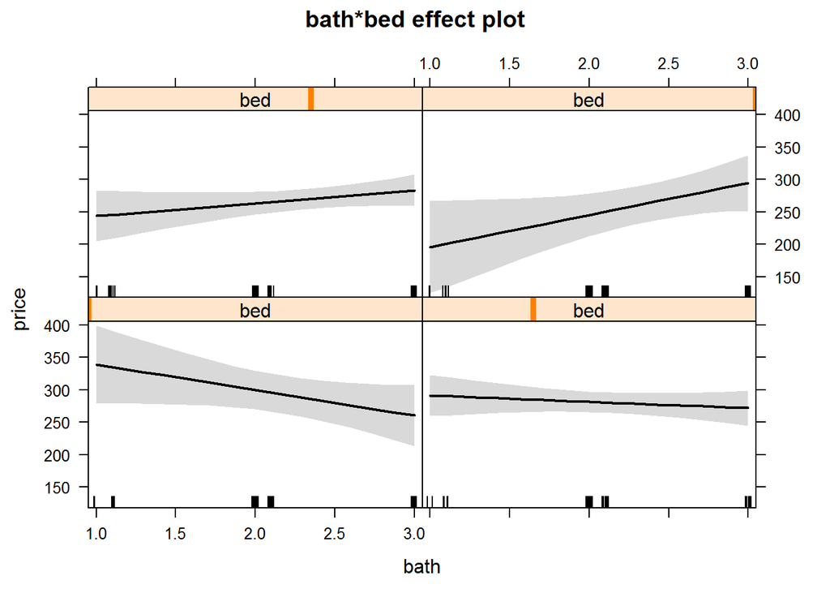

For the values of bed that lie between 2 and 5, the effect is still clear as it is decreasing at lower values but increasing at higher values of bath.

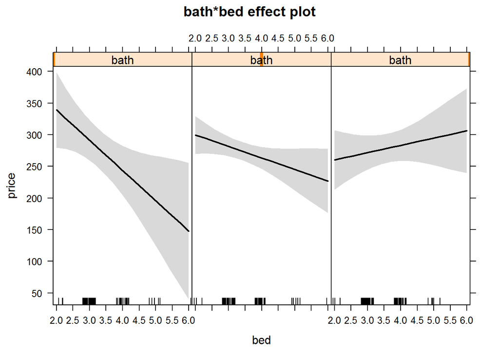

For the values of bath that lie between 1 and 3, the effect is declining at lower values of bed but increasing at higher values.